# Programming and Visualization for Data Science - Project

Davide Perez Cuevas

```r
library(tidyverse)
library(lubridate)
library(ggplot2)
library(gridExtra)
library(treemapify)
```

## Project task

The aim of this project is to explore some dataset (possibly a combination of more than one), using the visualization techniques we study in this course.

For this project you shall carry out at least the following.

- Select one or more data sources. You should find one or more datasets that are interesting for you. You are free to pick any dataset you prefer, on OLE there is a list of pointers to useful data repositories.
- Describe what the datasets are about and what you expect to find during the exploration.
- Clean and preprocess the dataset, recording the reasoning behind your preprocessing choices in the report.
- Visualize different aspects of the dataset using the most appropriate visualizations we study in the course.
- State your findings.

## Project description

“Agora” was known as one of the largest darknet markets. Active from 2013 to 2015, it operated primarily as a black market, allowing transactions of illegal items and services such as drugs, weapons, stolen/fake documents and other goods. The dataset under analysis is a Kaggle dataset (find it [here](https://www.kaggle.com/philipjames11/dark-net-marketplace-drug-data-agora-20142015)) created from a raw html rip of the Agora website (years 2014/2015), which was disclosed by an unknown Reddit user and which lead, probably, to the Agora shutdown a few months after. The Kaggle dataset curator states that he obtained the data from a 3rd party source, but acknowledges its origin from the [Darknet Web Archives](https://www.gwern.net/DNM-archives), a huge collection of scraped/mirrored data from the Dark Net Markets between years 2013-2015 and used as a reference from many papers related to studies on darknet markets. Moreover, he advises that some operations already have been made to the dataset: duplicated listings have been merged into a single listing, and the price has been averaged across merged duplicates.

Bitcoin is said to be the de facto currency of the dark web, and was used as currency in this market too. A time-series dataset, which we extracted from the archives of a [stock exchange website](https://www.investing.com/), is used as a support to achieve a precise conversion of the original bitcoin price to the euro currency.

The exploration of this dataset could lead to some interesting findings: besides the market analysis, which could translate to classifying items, their price trends and the related vendors, the shipping information allows to investigate the declared origin and destination of the illegal goods, identifying the high risk regions and routes.

**DISCLAIMER: darkweb is a treacherous dimension, and most of transaction on darknet markets involve illegal goods and activities. The following does not intend neither to encourage illegal activities in any way, nor to promote reckless darkweb surfing. Rather, it aims to perform an analysis to try to identify the insights of one of the biggest of such market platforms.**

## Dataset description

**DISCLAIMER n.2: in the follwing, we will use “dataset” as a broad term to refer both the data in analysis and the parsed data in R in form of a dataframe or tibble object.**

As first step, we read the dataset from the corresponding .csv file and get a first glimpse of the information in it.

```r
agora_raw <- read_csv("data/Agora.csv")
glimpse(agora_raw)
```

```
Rows: 109,689
Columns: 9
$ Vendor             <chr> "CheapPayTV", "CheapPayTV", "KryptykOG", "cyberzen", "businessdude", "Hackyboy", "businessdude", "CheapPayTV", "toysoldi…
$ Category           <chr> "Services/Hacking", "Services/Hacking", "Services/Hacking", "Services/Hacking", "Services/Hacking", "Services/Hacking", …
$ Item               <chr> "12 Month HuluPlus gift Code", "Pay TV Sky UK  Sky Germany HD TV  and much more.. CCcam Service 12 Months", "OFFICIAL Ac…
$ `Item Description` <chr> "12-Month HuluPlus Codes for $25. They are worth $95. They will be sent to you within 1 day. Most within a hour or two",…
$ Price              <chr> "0.05027025666666667 BTC", "0.152419585 BTC", "0.007000000000000005 BTC", "0.019016783532494728 BTC", "0.062018073963963…
$ Origin             <chr> "Torland", "Torland", "Torland", NA, "Torland", "Torland", NA, "Torland", "Torland", NA, "Torland", NA, "World", "Intern…
$ Destination        <chr> NA, NA, NA, NA, NA, NA, NA, NA, NA, NA, NA, NA, NA, NA, NA, NA, NA, "AUSTRALIA", NA, NA, NA, NA, NA, NA, NA, NA, NA, NA,…
$ Rating             <chr> "4.96/5", "4.96/5", "4.93/5", "4.89/5", "4.88/5", "4.92/5", "4.88/5", "4.96/5", "4.94/5", "4.89/5", "4.96/5", "4.946/5",…
$ Remarks            <chr> NA, NA, NA, NA, NA, NA, NA, NA, NA, NA, NA, NA, NA, NA, NA, NA, NA, NA, NA, NA, NA, NA, NA, NA, NA, NA, NA, NA, NA, "Ave…
```

We see that the Agora dataset contains more than 100000 entries and 9 columns. Here we give a description of the features as declared in Kaggle:

- `Vendor`: username of the seller
- `Category`: Agora’s marketplace category where the item belongs
- `Item`: item or service name
- `Description`: a description of the listing
- `Price`: cost of the item in bitcoins (BTC). The price has been averaged across any duplicated listings, and duplicates have been discarded.
- `Origin`: name or code of the country the item is declared to ship from
- `Destination`: name or code where the item is declared to ship to
- `Rating`: rating given to the seller on the Agora marketplace, on a 0-5 scale. Requires the seller to have close a minimum number of transactions.
- `Remarks`: additional notes about the listing

## Analysis overview

Web scrapes may be difficult to analyze: they often are large, redundant and highly error-prone. This is particularly true for scrapes coming from black webmarkets: being located in the darkweb and treating illegal matters, they are highly unstable. Products and vendors may be banned and disappear from day to day, metadata such as category descriptions or shipping information can be wrong or intentionally misleading, prices fluctuation is high due to cryptocurrencies. Data is often both not well organized and not sanitized due to anonimity concerns. Thus, such data will never be comprehensive and give an overall, long-term view on the market situation, but it rather represents a (more or less complete) snapshot of the market in a given moment. Our dataset is not an exception, and even by giving a quick `glimpse` we understand it is quite dirty.

Despite the intrinsic incompleteness, a complete enough dataset such as this one can give very helpful insights, but it requires quite a lot of cleaning and processing to be as reliable as possible. Given this, the analysis we will carry on will not follow a *waterfall* flow, in the sense that it will not be a procedure chaining cleaning, preprocessing and exploration tasks in a linear way. Rather, it will be an *iterative process* in which the analysis phases are intertwined, depending on the aspect we are analyzing. This is done in order to retain as much data as possible. For example, if we want to know the top vendors of the market we are not necessarily interested in knowing shipping-related information, and if we purged listings because of invalid information for such columns we would lose data and our analysis would become unreliable. Some things have to be handled as soon as possible, such as misparsed rows that could taint any type of exploration, but we will postpone the in-depth processing of single features until they are required.

## Handling missing and invalid values

We inspect the missing values per column by computing the percentage of null values:

```r
agora_raw %>%
  summarise_each(funs(100 * round(mean(is.na(.)), 6)))
```

| Vendor | Category | Item | Item Description | Price | Origin | Destination | Rating | Remarks |
| --- | --- | --- | --- | --- | --- | --- | --- | --- |
| 0 | 0 | 0.0018 | 0.0246 | 0.0046 | 9.0091 | 44.8185 | 0.0137 | 88.4984 |

We see that some columns contains a lot of missing values: for `Remarks` column almost all data is missing, while for `Destination` column a solid 44,81% of the listings have a missing value. The `Remarks` feature is not relevant, so we can safely drop it.

```r
agora <-
  agora_raw %>%
  select(-c('Remarks'))
```

The `Item` feature is an information that is required for a valid listing in any marketplace: a missing value probably indicates a misparsed entry. Same reasoning goes for the `Price` feature.

```r
agora %>%
  filter(is.na(`Item`) | is.na(`Price`))
```

| Vendor | Category | Item | Item Description | Price | Origin | Destination | Rating |
| --- | --- | --- | --- | --- | --- | --- | --- |
| Kind Hearts and Gentle People | the Body Bags shotty and Mac make-up To: Kind Hearts and Gentle People | 4.84/5 | NA | NA | NA | NA | NA |
| Kind Hearts and Gentle People | home of the Body Bags shotty and mag Kind Hearts and Gentle People | 4.7/5 | NA | NA | NA | NA | NA |
| Godspeed | Drugs/Ecstasy/Pills | Enter The Matrix Pill Pack! 10X Blue/Red Louis Vitton Ecstacy/XTC/MDMA | This is your last chance. After this there is no turning back. You take the blue pill -- the story ends you wake up in your bed and believe whatever you want to believe. You take the red pill -- y ...… | NA | NA | NA | NA |
| Thrills | Info/eBooks/Making money | The Power of Persuasion: How We're Bought and Sold | An engaging highly readable survey of the sophisticated methods of persuasion we encounter in various situations. From television to telemarketing and from self-deception to suicide cults Levine t ...… | NA | NA | NA | NA |
| Ray Ban RB4175 Flash Lenses Sunglasses Replica◆ ★ For whom(M/F): Unisex ★ Color: ☆Frame: Brown \| Lens: Brown ★ Description: This Ray Ban RB4175 Flash Lenses Sunglasses Replica are 1:1 ... | 0.1905617980645162 BTC | NA | NA | [0 deals] | NA | NA | NA |
| ShopWithUs | Forgeries/Physical documents | NA | NA | 1.5849700500000001 BTC | World | NA | 4.79/5 |
| Kind Hearts and Gentle People | the Body Bags shotty and mag To: Kind Hearts and Gentle People | 4.82/5 | NA | NA | NA | NA | NA |

Indeed, these rows are either scrambled or incomplete. We proceed removing all of them.

```r
agora <-
  agora %>%
  filter(!is.na(Item) & !is.na(Price))
```

*Item Description* contains text giving additional info, so it is not object of analysis and can be fully dropped.

```r
agora <-
  agora %>%
  select(-c('Item Description'))
```

We managed to do a preliminary shrinking of the dataset by getting rid of redundant information.

## Exploration

### Agora’s Top Vendors

We want to know who are the most active vendors in terms of listings.

```r
agora %>%
  distinct(Vendor) %>%
  count()
```

| n |
| --- |
| 3190 |

On the marketplace there are almost 3200 vendors. We focus our attention on the top 20 ones.

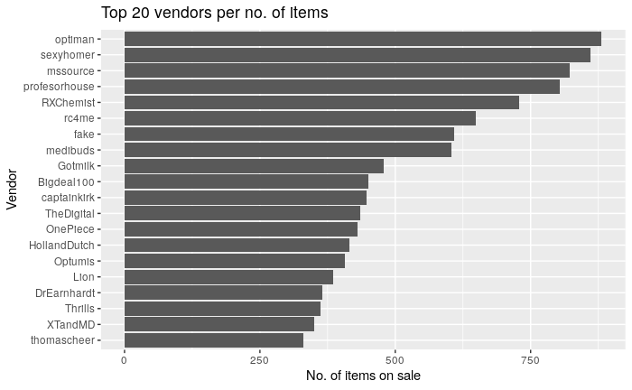

```r
agora %>%
  group_by(Vendor) %>%
  summarise(N_items = n()) %>%
  arrange(desc(N_items)) %>%
  slice_head(n = 20) %>%
  ggplot(aes(x = N_items, y = reorder(Vendor, N_items))) +
  geom_col() +
  labs(title = 'Top 20 vendors per no. of items', x = 'No. of items on sale', y = 'Vendor')
```

We see that the top four vendors have a similar number of items listed, while from the fifth on there is a noticeable gap.

We visualize the same data by means of the so-called treemap. The bigger the rectangle, the bigger the number of items on sale from the related vendor. While this visualization is less effectve than the bar chart in terms of quantifying sold items, it highlights better other insights about this data. For example, it is evident that the top four vendors (stacked at the left handside of the plot) have a comparable sales volume.

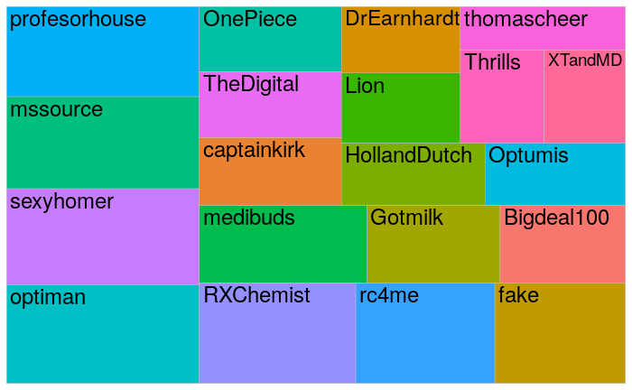

```r
top_20_vendors %>%
  ggplot(aes(area = N_items, fill = Vendor, label = Vendor)) +
  geom_treemap(show.legend = FALSE) +
  geom_treemap_text()
```

Another indicator of a vendor’s weight on the market could be the *Rating* feature. It expresses the average rating given to the seller from other users on the marketplace.

```r
agora %>%
  select(Vendor, Rating) %>%
  distinct() %>%
  arrange(desc(Rating))
```

| Vendor | Rating |
| --- | --- |
| snapback | Worldwide |
| snapback | USA |
| Amstergram | 6~10 deals |
| BurmaImports | 6~10 deals |
| drugswings | 6~10 deals |
| NeoNino | 6~10 deals |
| drugs-depot | 6~10 deals |
| projectHustle | 6~10 deals |
| bestdrugs | 6~10 deals |
| TrappeddownSouth | 6~10 deals |

[output cut: 990 more lines]

First thing we notice are two misparsed rows, which we remove.

```r
agora <-
  agora %>%
  filter(Rating != 'Worldwide') %>%
  filter(Rating != 'USA')
```

Secondly, we must clean the feature in some way.

```r
agora %>%
  select(Rating) %>%
  distinct()
```

| Rating |
| --- |
| 4.96/5 |
| 4.93/5 |
| 4.89/5 |
| 4.88/5 |
| 4.92/5 |
| 4.94/5 |
| 4.946/5 |
| 5.00/5 |
| 4.47/5 |
| 4.58/5 |

[output cut: 466 more lines]

We start handling missing/literal values: they mean that the related vendor has not closed enough deals yet to compute a meaningful rating. In this case, it makes sense to use NA as an indicator that the rating is not present at all.

```r
agora <-
  agora %>%
  mutate(Rating = ifelse(str_detect(Rating, "deals"), NA, Rating))
```

Then we clean the other invalid values.

```r
agora <-
  agora %>%
  mutate(Rating = str_remove_all(Rating, "~")) %>%
  mutate(Rating = str_remove_all(Rating, "/5")) %>%
  mutate(Rating = as.numeric(Rating))
```

We successfully processed the Rating feature.

```r
agora %>%
  select(Rating) %>%
  distinct() %>%
  arrange(desc(Rating))
```

| Rating |
| --- |
| 5.000 |
| 4.999 |
| 4.998 |
| 4.997 |
| 4.996 |
| 4.995 |
| 4.994 |
| 4.993 |
| 4.992 |
| 4.991 |

[output cut: 414 more lines]

We now visualize it.

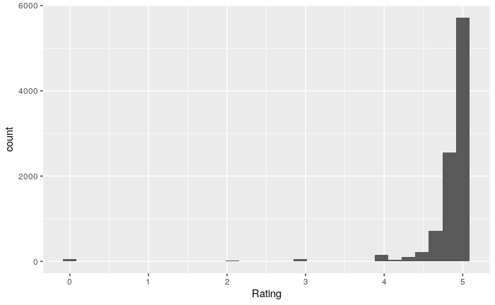

```r
agora %>%
  select(Vendor, Rating) %>%
  distinct() %>%
  ggplot(aes(x = Rating)) +
  geom_histogram()
```

We see that bad ratings are very rare: most ratings are among 4 and 5, with a very high number of vendors with top ratings. **This may mean that the market is a “safe” place where to buy the kind of items it offers**.

```r
agora %>%
  distinct(Category) %>%
  count()
```

| n |
| --- |
| 104 |

There are 104 different categories, which is quite a large number for classifying items.

```r
agora %>%
  distinct(Category) %>%
  arrange(Category)
```

| Category |
| --- |
| Chemicals |
| Counterfeits/Accessories |
| Counterfeits/Clothing |
| Counterfeits/Electronics |
| Counterfeits/Money |
| Counterfeits/Watches |
| Data/Accounts |
| Data/Pirated |
| Data/Software |
| Drug paraphernalia/Containers |

[output cut: 94 more lines]

We immediately notice a couple misparsed entry: we proceed to selectively remove it.

```r
agora <-
  agora %>%
  filter(Category != '0.12780125125 BTC') %>%
  filter(Category != '0.1905617980645162 BTC')
```

Now we do a quick inspection of the number of items per category.

```r
categories <-
  agora %>%
  group_by(Category) %>%
  summarise(N_items = n()) %>%
  arrange(desc(N_items))
categories
```

| Category | N_items |
| --- | --- |
| Drugs/Cannabis/Weed | 21268 |
| Drugs/Ecstasy/Pills | 7533 |
| Drugs/Ecstasy/MDMA | 6116 |
| Drugs/Stimulants/Cocaine | 6007 |
| Drugs/Prescription | 5561 |
| Drugs/Benzos | 5390 |
| Drugs/Cannabis/Concentrates | 4256 |
| Drugs/Psychedelics/LSD | 3775 |
| Drugs/Cannabis/Hash | 3241 |
| Drugs/Steroids | 2779 |

[output cut: 94 more lines]

From this preliminary check, we can already see that drug-related products seems to have a great weight in the market.

```r
arrange(categories, N_items)
```

| Category | N_items |
| --- | --- |
| Drugs/Dissociatives/PCP | 4 |
| Drug paraphernalia/Injecting equipment/Filters | 6 |
| Forgeries | 8 |
| Info/eBooks/Aliens/UFOs | 10 |
| Weapons/Fireworks | 14 |
| Drug paraphernalia/Injecting equipment/Needles | 15 |
| Info/eBooks/Philosophy | 25 |
| Info/eBooks/Politics | 26 |
| Tobacco/Paraphernalia | 27 |
| Drug paraphernalia/Injecting equipment/Other | 30 |

[output cut: 94 more lines]

By inspecting the less popular categories, we found some other misparsed entries which we remove from the original dataset.

```r
agora <-
  agora %>%
  filter(!str_detect(Category, "Body Bags"))
```

However, there still is a problem. It looks like each category is divided in one or more subcategories (or tiers). For example, the category *Drugs/Cannabis/Weed* identifies a main category *Drugs* and two subcategories *Cannabis* and *Weed*. We may want to do some more fine-grained exploration of the categories, for example exploring one tier at time. We check how many tiers there are.

```r
categories <-
  categories %>%
  mutate(Depth = str_count(Category, "/") + 1) %>%
  arrange(desc(Depth))
categories
```

| Category | N_items | Depth |
| --- | --- | --- |
| Info/eBooks/Relationships/Sex | 145 | 4 |
| Drugs/Cannabis/Shake/trim | 121 | 4 |
| Info/eBooks/Aliens/UFOs | 10 | 4 |
| Drugs/Cannabis/Weed | 21268 | 3 |
| Drugs/Ecstasy/Pills | 7533 | 3 |
| Drugs/Ecstasy/MDMA | 6116 | 3 |
| Drugs/Stimulants/Cocaine | 6007 | 3 |
| Drugs/Cannabis/Concentrates | 4256 | 3 |
| Drugs/Psychedelics/LSD | 3775 | 3 |
| Drugs/Cannabis/Hash | 3241 | 3 |

[output cut: 94 more lines]

We see there are up to four category tiers. We will analyze the different categories in detail: it makes sense to explore them depending on the tier level in order to keep the analysis tidy.

```r
categories <-
  agora %>%
  select(Category) %>%
  mutate(Depth = str_count(Category, "/") + 1) %>%
  separate(Category, into = c("Tier1", "Tier2", "Tier3", "Tier4"), sep = "/")
```

```
Expected 4 pieces. Missing pieces filled with `NA` in 109395 rows [1, 2, 3, 4, 5, 6, 7, 8, 9, 10, 11, 12, 13, 14, 15, 16, 17, 18, 19, 20, ...].
```

```r
categories
```

| Tier1 | Tier2 | Tier3 | Tier4 | Depth |
| --- | --- | --- | --- | --- |
| Services | Hacking | NA | NA | 2 |
| Services | Hacking | NA | NA | 2 |
| Services | Hacking | NA | NA | 2 |
| Services | Hacking | NA | NA | 2 |
| Services | Hacking | NA | NA | 2 |
| Services | Hacking | NA | NA | 2 |
| Services | Hacking | NA | NA | 2 |
| Services | Hacking | NA | NA | 2 |
| Services | Hacking | NA | NA | 2 |
| Services | Hacking | NA | NA | 2 |

[output cut: 990 more lines]

To speed things up, we build a couple functions to extract a tidy tier-specific dataset and to plot it in various formats.

```r
get_tier_data <- function(dataset, tier_no, results_no){
  col_name = sprintf("Tier%d", tier_no)
  tier_data <-
    dataset %>%
    select(col_name) %>%
    drop_na(col_name) %>%
    group_by_at(col_name) %>%
    summarise(N_items = n()) %>%
    arrange(desc(N_items)) %>%
    slice_head(n = results_no)
  return(tier_data)
}

plot_tier_bar <- function(dataset, tier_no, results_no){
  col_name = sprintf("Tier%d", tier_no)
  p <-
    ggplot(get_tier_data(dataset, tier_no, results_no), aes(x = N_items, y = reorder(!!sym(col_name), N_items))) + # col_name is a string, must be a symbol so we use r features to convert it
    geom_col() +
    scale_fill_brewer(palette = "Dark2") +
    labs(title = sprintf("Top %d entries of cat. tier %d", results_no, tier_no), x = "No. of items", y = "Category")
  return(p)
}

plot_tier_pie <- function(dataset, tier_no, results_no){
  col_name = sprintf("Tier%d", tier_no)
  pie_tier <-
    ggplot(get_tier_data(dataset, tier_no, results_no), aes(x = "", y = (N_items / sum(N_items) * 100), fill = !!sym(col_name))) +
    geom_bar(stat = "identity", width = 1, color = "white") +
    coord_polar("y", start = 0) +
    theme_void() +
    labs(title = sprintf("Market shares for top %d items", results_no, tier_no), y = "Test") +
    geom_text(aes(label = round((N_items / sum(N_items) * 100), digits = 2)), position = position_stack(vjust = 0.5)) +
    scale_fill_brewer(palette = "Set1")
  return(pie_tier)
}
```

We get a global overview by plotting all of the tiers in a grid. We concentrate on the top 15 entries.

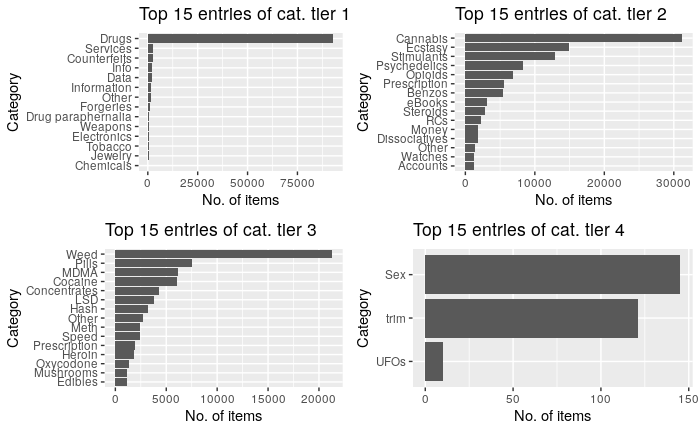

```r
p1 <- plot_tier_bar(categories, 1, 15)
p2 <- plot_tier_bar(categories, 2, 15)
p3 <- plot_tier_bar(categories, 3, 15)
p4 <- plot_tier_bar(categories, 4, 15)
grid.arrange(p1, p2, p3, p4, ncol = 2)
```

By means of these simple grid of plots we see some important characteristics of the market: the drugs dominates all the other product types, and in this category cannabis and weed are by far the most sold products. We can have a better visualization of this by means of pie charts showing the market shares for each category tier.

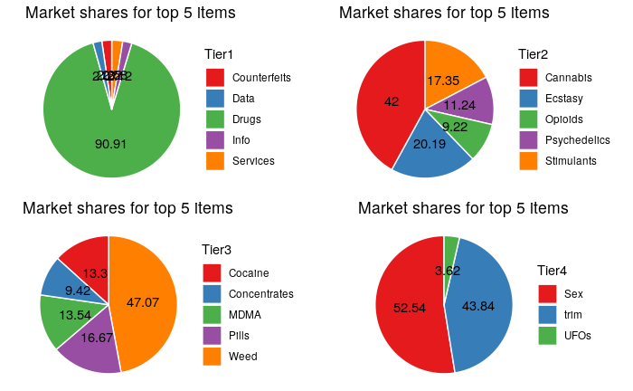

```r
pie1 <- plot_tier_pie(categories, 1, 5)
pie2 <- plot_tier_pie(categories, 2, 5)
pie3 <- plot_tier_pie(categories, 3, 5)
pie4 <- plot_tier_pie(categories, 4, 5)
grid.arrange(pie1, pie2, pie3, pie4, ncol = 2)
```

Market share of tier 4 is not so relevant because there are very few items having this classification compared to the total number of listings:

```r
categories %>%
  filter(!is.na(Tier4)) %>%
  count()
```

| n |
| --- |
| 276 |

We may hypotize this happened so due to a wrong classification, either by the user selling the product or by the website itself. However, for our analysis’ sake, we may eliminate this less-relevant tier 4 and reassign those items to the upper-level tier. Note that we are not elimining any entry, we are *reclassifying* it.

```r
agora <-
  agora %>%
  mutate(Category, Category = ifelse(str_detect(Category, "Sex"),"Info/eBooks/Relationships", Category)) %>%
  mutate(Category, Category = ifelse(str_detect(Category, "trim"),"Drugs/Cannabis/Shake", Category)) %>%
  mutate(Category, Category = ifelse(str_detect(Category, "UFOs"),"Info/eBooks/Aliens", Category))
```

Once we drawn a preliminary profile of the market categories, we now focus on prices. As in every darkweb market, prices are in expressed in bitcoins. Moreover, the feature is a string which encodes both the price and the currency. We need to make it tidy by converting it and getting rid of the currency, which is always the same.

```r
agora <-
  agora %>%
  separate(Price, into = c("PriceBTC", "Currency"), sep = " ") %>%
  mutate(PriceBTC = as.numeric(PriceBTC)) %>%
  select(-c("Currency"))
agora
```

| Vendor | Category | Item | PriceBTC | Origin | Destination | Rating |
| --- | --- | --- | --- | --- | --- | --- |
| CheapPayTV | Services/Hacking | 12 Month HuluPlus gift Code | 5.027026e-02 | Torland | NA | 4.960 |
| CheapPayTV | Services/Hacking | Pay TV Sky UK Sky Germany HD TV and much more.. CCcam Service 12 Months | 1.524196e-01 | Torland | NA | 4.960 |
| KryptykOG | Services/Hacking | OFFICIAL Account Creator Extreme 4.2 | 7.000000e-03 | Torland | NA | 4.930 |
| cyberzen | Services/Hacking | VPN > TOR > SOCK TUTORIAL | 1.901678e-02 | NA | NA | 4.890 |
| businessdude | Services/Hacking | Facebook hacking guide | 6.201807e-02 | Torland | NA | 4.880 |
| Hackyboy | Services/Hacking | DDOS ATTACK SERVICE | 3.010943e-02 | Torland | NA | 4.920 |
| businessdude | Services/Hacking | ATM HACKING TUTORIAL | 3.317626e-02 | NA | NA | 4.880 |
| CheapPayTV | Services/Hacking | CALL/SMS verification service! | 1.261699e-02 | Torland | NA | 4.960 |
| toysoldiers | Services/Hacking | Mac & windows address changer | 9.335871e-03 | Torland | NA | 4.940 |
| cyberzen | Services/Hacking | WiFi Hacking | 2.709132e-02 | NA | NA | 4.890 |

[output cut: 990 more lines]

We validate the new feature by checking for null values.

```r
agora %>%
  filter(is.na(PriceBTC))
```

| Vendor | Category | Item | PriceBTC | Origin | Destination | Rating |
| --- | --- | --- | --- | --- | --- | --- |

```r
agora <-
  agora %>%
  filter(!is.na(PriceBTC))
```

So we need to convert the original price to another currency. The problem is that Bitcoin is very volatile: its value quickly changes on a daily basis, and *we are dealing with data covering a timespan of two years and without an indication about the exact date at which a particular item was on sale*. Thus, we need a method to achieve a meaningful enough conversion factor to craft a new price feature. For this task, we use a dataset which we extracted from [Investing.com](https://www.investing.com/), a reputable website offering stock market services. Since Bitcoin/Euro exchange rate is listed on the stock exchange, we can easily find data related to its value over a certain period.

```r
btc_eur <- read_csv("data/BTCHist01012014.csv")
btc_eur
```

| Date | Price | Open | High | Low | Vol. | Change % |
| --- | --- | --- | --- | --- | --- | --- |
| Nov 30, 2020 | 18646.0 | 18186.0 | 18676.7 | 18186.0 | 87.18K | 2.53% |
| Nov 29, 2020 | 18185.5 | 17729.7 | 18336.3 | 17530.4 | 79.12K | 2.57% |
| Nov 28, 2020 | 17730.7 | 17142.6 | 17874.4 | 16874.4 | 95.20K | 3.52% |
| Nov 27, 2020 | 17127.1 | 17160.9 | 17450.3 | 16481.6 | 138.80K | -0.20% |
| Nov 26, 2020 | 17162.0 | 18721.9 | 18894.9 | 16235.2 | 312.07K | -8.34% |
| Nov 25, 2020 | 18723.0 | 19151.5 | 19486.7 | 18527.7 | 146.12K | -2.24% |
| Nov 24, 2020 | 19152.6 | 18394.6 | 19416.6 | 18074.8 | 180.79K | 4.21% |
| Nov 23, 2020 | 18379.6 | 18428.1 | 18756.8 | 18016.0 | 127.35K | -0.18% |
| Nov 22, 2020 | 18412.9 | 18689.3 | 18751.5 | 17644.6 | 121.76K | -1.47% |
| Nov 21, 2020 | 18687.2 | 18673.8 | 18966.0 | 18397.5 | 108.91K | 0.06% |

[output cut: 990 more lines]

This dataset is a snapshot of the financial market related to BTC/EUR exchange rate over the time period 01/01/2014 - 30/11/2020. A market analysis on the fluctuation of Bitcoin value is complex and out of the scope of this project, but to have an idea of the volatility of this cryptocurrency we can see the first and last entry of this dataset:

```r
head(btc_eur, n = 1)
```

| Date | Price | Open | High | Low | Vol. | Change % |
| --- | --- | --- | --- | --- | --- | --- |
| Nov 30, 2020 | 18646 | 18186 | 18676.7 | 18186 | 87.18K | 2.53% |

```r
tail(btc_eur, n = 1)
```

| Date | Price | Open | High | Low | Vol. | Change % |
| --- | --- | --- | --- | --- | --- | --- |
| Jan 01, 2014 | 815.9 | 805.9 | 829.9 | 771 | 10.76K | 1.24% |

```r
btc_eur %>%
  filter(Date == "Jan 01, 2014") %>%
  head(n = 1)
```

| Date | Price | Open | High | Low | Vol. | Change % |
| --- | --- | --- | --- | --- | --- | --- |
| Jan 01, 2014 | 815.9 | 805.9 | 829.9 | 771 | 10.76K | 1.24% |

On 01/01/2014, one bitcoin was worth `815.9` euros.

```r
btc_eur %>%
  filter(Date == "Jan 01, 2015") %>%
  head(n = 1)
```

| Date | Price | Open | High | Low | Vol. | Change % |
| --- | --- | --- | --- | --- | --- | --- |
| Jan 01, 2015 | 314.9 | 318.2 | 321.4 | 313.5 | 12.82K | -1.05% |

Exactly one year later, its value is less than a half! This clearly may represent a problem in our analysis, because we lack a time reference indicating the exact item date of sale. So we use this dataset as a mean to obtain an exchange rate which is as reliable as possible. First we clean and filter the dataset to suit our needs. We are only interested to the date and the price in a specific timespan: from a [quick search](https://en.wikipedia.org/wiki/Agora_%28online_marketplace%29) we see that the website shut down in August 2015, so we can narrow the interval.

```r
btc_eur <-
  btc_eur %>%
  select(`Date`, Price) %>%
  mutate(`Date` = mdy(`Date`)) %>%
  filter(`Date` < as_date("2015-08-31"))
btc_eur
```

| Date | Price |
| --- | --- |
| 2015-08-30 | 228.4 |
| 2015-08-29 | 228.5 |
| 2015-08-28 | 231.6 |
| 2015-08-27 | 222.7 |
| 2015-08-26 | 225.0 |
| 2015-08-25 | 220.5 |
| 2015-08-24 | 211.4 |
| 2015-08-23 | 226.8 |
| 2015-08-22 | 229.5 |
| 2015-08-21 | 232.4 |

[output cut: 597 more lines]

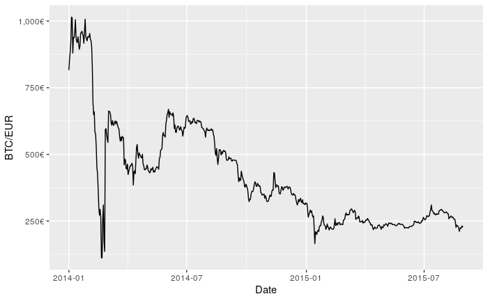

```r
btc_eur %>%
  ggplot(aes(x = Date, y = Price)) +
  geom_line(na.rm = TRUE) +
  labs(x = "Date", y = "BTC/EUR") +
  scale_y_continuous(labels = scales::dollar_format(suffix = "€", prefix = ""))
```

As we expected, exchange rate was quite variable in these years too. We compute the average value and take it as conversion factor:

```r
btc_eur_rate <-
  mean(btc_eur[["Price"]])
btc_eur_rate
```

```
[1] 413.7842
```

We can now create a new column in our dataset.

```r
agora <-
  agora %>%
  mutate(PriceEUR = round(PriceBTC * btc_eur_rate, 2), .after = PriceBTC) %>%
  mutate(PriceBTC = round(PriceBTC, 4))
agora
```

| Vendor | Category | Item | PriceBTC | PriceEUR | Origin | Destination | Rating |
| --- | --- | --- | --- | --- | --- | --- | --- |
| CheapPayTV | Services/Hacking | 12 Month HuluPlus gift Code | 0.0503 | 20.80 | Torland | NA | 4.960 |
| CheapPayTV | Services/Hacking | Pay TV Sky UK Sky Germany HD TV and much more.. CCcam Service 12 Months | 0.1524 | 63.07 | Torland | NA | 4.960 |
| KryptykOG | Services/Hacking | OFFICIAL Account Creator Extreme 4.2 | 0.0070 | 2.90 | Torland | NA | 4.930 |
| cyberzen | Services/Hacking | VPN > TOR > SOCK TUTORIAL | 0.0190 | 7.87 | NA | NA | 4.890 |
| businessdude | Services/Hacking | Facebook hacking guide | 0.0620 | 25.66 | Torland | NA | 4.880 |
| Hackyboy | Services/Hacking | DDOS ATTACK SERVICE | 0.0301 | 12.46 | Torland | NA | 4.920 |
| businessdude | Services/Hacking | ATM HACKING TUTORIAL | 0.0332 | 13.73 | NA | NA | 4.880 |
| CheapPayTV | Services/Hacking | CALL/SMS verification service! | 0.0126 | 5.22 | Torland | NA | 4.960 |
| toysoldiers | Services/Hacking | Mac & windows address changer | 0.0093 | 3.86 | Torland | NA | 4.940 |
| cyberzen | Services/Hacking | WiFi Hacking | 0.0271 | 11.21 | NA | NA | 4.890 |

[output cut: 990 more lines]

Now that we have reliable pricing info, we can go back on the categories information to obtain new insights (remember that cat. tier 4 has been merged with tier 3).

```r
categories <-
  agora %>%
  mutate(Depth = str_count(Category, "/") + 1) %>%
  mutate(Depth = as_factor(Depth)) %>%
  separate(Category, into = c("Tier1", "Tier2", "Tier3"), sep = "/")
```

```
Expected 3 pieces. Missing pieces filled with `NA` in 32351 rows [1, 2, 3, 4, 5, 6, 7, 8, 9, 10, 11, 12, 13, 14, 15, 16, 17, 18, 19, 20, ...].
```

We use a boxplot to visualize the prices per category tier.

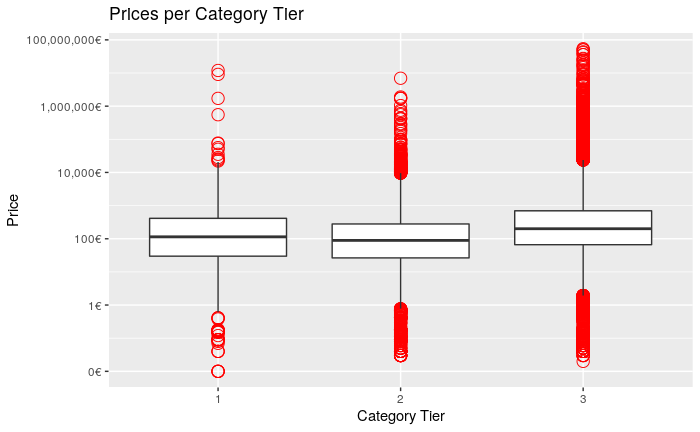

```r
categories %>%
  ggplot(aes(x = Depth, y = PriceEUR)) +
  geom_boxplot(outlier.colour = "red", outlier.shape = 1, outlier.size = 4) +
  scale_y_log10(labels = scales::dollar_format(suffix = "€", prefix = ""),
                breaks = scales::trans_breaks("log10", function(x) 10^x)) +
  labs(title = "Prices per Category Tier", x = "Category Tier", y = "Price")
```

We see a noticeable number of red circles. However, this does not automatically classify them as outliers: identification of outliers is tricky and should not be done only relying on boxplots only. This is even more true when dealing with market prices, where many market-related parameters should be taken into account. More probably, these outliers are just values that do not fall in a normal distribution: in other words, there is a number of items whose price is very high and far away from the median price and the 75th percentile.

Zooming on the other categories, we notice the same behavior:

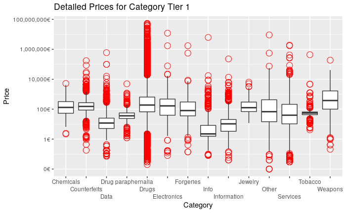

```r
categories %>%
  select(Tier1, PriceEUR) %>%
  drop_na() %>%
  ggplot(aes(x = Tier1, y = PriceEUR)) +
  geom_boxplot(outlier.colour = "red", outlier.shape = 1, outlier.size = 4) +
  scale_y_log10(labels = scales::dollar_format(suffix = "€", prefix = ""),
                breaks = scales::trans_breaks("log10", function(x) 10^x)) +
  scale_x_discrete(guide = guide_axis(n.dodge=3)) +
  labs(title = "Detailed Prices for Category Tier 1", x = "Category", y = "Price")
```

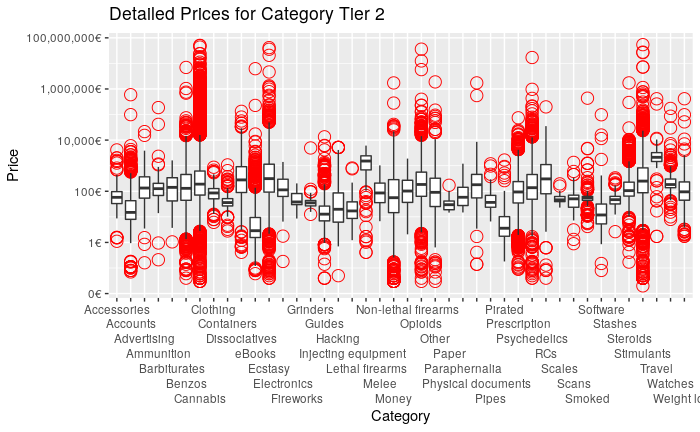

```r
categories %>%
  select(Tier2, PriceEUR) %>%
  drop_na() %>%
  ggplot(aes(Tier2, PriceEUR)) +
  geom_boxplot(outlier.colour = "red", outlier.shape = 1, outlier.size = 4) +
  scale_y_log10(labels = scales::dollar_format(suffix = "€", prefix = ""),
                breaks = scales::trans_breaks("log10", function(x) 10^x)) +
  scale_x_discrete(guide = guide_axis(n.dodge = 7)) +
  labs(title = "Detailed Prices for Category Tier 2", x = "Category", y = "Price")
```

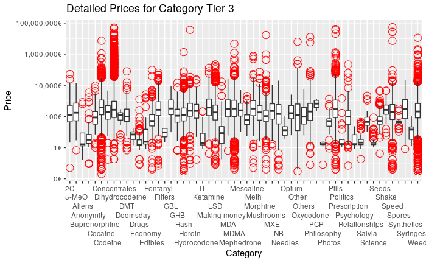

```r
categories %>%
  select(Tier3, PriceEUR) %>%
  drop_na() %>%
  ggplot(aes(Tier3, PriceEUR)) +
  geom_boxplot(outlier.colour = "red", outlier.shape = 1, outlier.size = 4) +
  scale_y_log10(labels = scales::dollar_format(suffix = "€", prefix = ""),
                breaks = scales::trans_breaks("log10", function(x) 10^x)) +
  scale_x_discrete(guide = guide_axis(n.dodge = 7)) +
  labs(title = "Detailed Prices for Category Tier 3", x = "Category", y = "Price")
```

However, these boxplot give a nice visual feedback about the price distribution on different levels. For example, in each of them we can see that prices for some categories, such as Drugs, fluctuates a lot. On the other hand, it classifies the `Price` as quite unreliable: even through the process we followed to convert it from BTC to Euros, we still cannot be sure we obtained a precise value due to the intrinsic instability of the cryptocurrency and the lack of a precise time reference.

```r
destination <-
  agora %>%
  select(Destination) %>%
  mutate(Destination = str_to_upper(Destination)) %>%
  arrange(Destination) %>%
  distinct()

origin <-
  agora %>%
  select(Origin) %>%
  mutate(Origin = str_to_upper(Origin)) %>%
  arrange(Origin) %>%
  distinct()
```

`Origin` contains 360 distinct values, while `Destination` contains 971 of them. Despite the number, in this case the most viable method to both keep data and make it reliable is to clean them manually: an effective automatic processing which also retains an accettable number of entries is not easy to apply in this case. So the approach we will use is the following: first, we export the two columns in a .csv file each.

```r
destination %>%
  write_csv("data/destination_raw.csv")

origin %>%
  write_csv("data/origin_raw.csv")
```

Then *we edit the file with a text editor*, and add a new `CountryCode` which we manually edit by adopting the following rules:

- Each country string is mapped to its ISO alpha-3 country code.
- Continents are mapped to a 2-digit code (EUROPE -> EU).
- Worldwide shipping is represented by the code `WW`.
- In case where more than a country/continent is listed, their corresponding ISO codes will be concatenated with a comma as separator (Europe, Usa, Asia -> EU,USA,AS)
- In case a country/continent is excluded, a ! is prepended to its country code (WORLDWIDE EXCEPT AUSTRALIA -> WW,!AUS)
- When possible, a country list is summarized by the most general one. For example, EUROPE AND GERMANY -> EU since Germany is in Europe.
- Continent classification respects political boundaries of years 2014-2015. For example, Great Britain was still a member of European Union.
- Unknown countries and those who cannot be described by means of the aforementioned rules are left empty or ignored: this happens especially for geographical area which cannot be expressed in terms of proper countries or continents, such as “South America” or “Scandinavia”.
- As explained on the Kaggle dataset description, a missing `Destination` or `Origin` value probably means that the item ships worldwide. This is also mentioned on other website that hosted the dataset, such as [this one](https://archive.org/details/dnmarchives). Given this, we assume this exact meaning, and replace `NA` with `WW` for both `Origin` and `Destination`.